# Problem Set #1

Author

Tiffany Wu

## Github Repo Link to Problem Set 1:

https://github.com/tiffany-wu/Stats506/tree/main/PS1

## Problem 1 - Wine Data

### a. Import the data into a data.frame in R. Use the information in the “wine.names” file to give appropriate column names. (Note: Downloading and unzipping the file can take place outside of your submitted document, but importing the file should be in the submission.)

```r
rm(list = ls())

# Import wine data
wine <- read.csv("C:/Users/tiffa/University of Michigan Dropbox/Tiffany Wu/Tiffany Wu’s files/Documents/Stats506/PS1/wine.data",
                 header = FALSE)

# Rename columns using wine.names file
colnames(wine) <- c("Class", "Alcohol", "Malic_Acid", "Ash",
                    "Alcalinity_of_Ash", "Magnesium", "Total_Phenols",
                    "Flavanoids", "Nonflavanoid_Phenols",
                    "Proanthocyanins", "Color_Intensity", "Hue",
                    "Diluted_Wines", "Proline")
```

### b. The data contains information on three different classes of wine. Check and report that the number of wines within each class is correct as reported in “wine.names”.

```r
# Check num of wines in each class
# Should be class 1 59, class 2 71, class 3 48

table(wine$Class)
```

```
 1  2  3
59 71 48
```

### c. Use the data to answer the following questions:

#### 1. What is the correlation between alcohol content and color intensity?

The correlation is 0.5463642.

```r
# Corr b/w Alcohol and Color_Intensity
cor(wine$Alcohol, wine$Color_Intensity)
```

```
[1] 0.5463642
```

#### 2. Which class has the highest correlation? Which has the lowest?

Class 1 has the highest correlation, at approximately 0.408. Class 2 has the lowest correlation, at approximately 0.270.

```r
# Split the data by class
class_1 <- subset(wine, Class == 1)
class_2 <- subset(wine, Class == 2)
class_3 <- subset(wine, Class == 3)

# Get the correlations for each class
cor_class_1 <- cor(class_1$Alcohol, class_1$Color_Intensity)
cor_class_2 <- cor(class_2$Alcohol, class_2$Color_Intensity)
cor_class_3 <- cor(class_3$Alcohol, class_3$Color_Intensity)

# Show output of all correlations for the html file, don't assign
cor(class_1$Alcohol, class_1$Color_Intensity)
```

```
[1] 0.4082913
```

```r
cor(class_2$Alcohol, class_2$Color_Intensity)
```

```
[1] 0.2697891
```

```r
cor(class_3$Alcohol, class_3$Color_Intensity)
```

```
[1] 0.3503777
```

#### 3. What is the alcohol content of the wine with the highest color intensity?

The alcohol content is 14.34.

```r
# What is the wine with the highest color intensity? Wine 159.
max_color <- which.max(wine$Color_Intensity)

# What is alcohol content for Wine 159?
wine$Alcohol[max_color]
```

```
[1] 14.34
```

#### 4. What percentage of wines had a higher content of proanthocyanins compare to ash?

Approximately 8.43% of wines had a higher content of proanthocyanins.

```r
# Number of wines with higher proanthocyanins is 15
higher_p_count <- sum(wine$Proanthocyanins > wine$Ash)

# Divide 15 by total number of wines, multiply by 100 for percentage
(higher_p_count / nrow(wine)) * 100
```

```
[1] 8.426966
```

### d. Create a table identifying the average value of each variable, providing one row for the overall average, and one row per class with class averages. (This table does not need to be “fancy” but should clearly identify what each value represents.)

```r
# Get overall average for each column (-1 to exclude Class column)
overall_averages <- colMeans(wine[, -1])

# Get the averages for each class
class_1_avg <- colMeans(class_1[, -1])
class_2_avg <- colMeans(class_2[, -1])
class_3_avg <- colMeans(class_3[, -1])

# Combine the averages into a single table
average_table <- rbind(
  Overall = overall_averages,
  "Class 1" = class_1_avg,
  "Class_2" = class_2_avg,
  "Class_3" = class_3_avg
)

# Round
average_table <- round(average_table, 3)

# Print table
print(average_table)
```

```
        Alcohol Malic_Acid   Ash Alcalinity_of_Ash Magnesium Total_Phenols
Overall  13.001      2.336 2.367            19.495    99.742         2.295
Class 1  13.745      2.011 2.456            17.037   106.339         2.840
Class_2  12.279      1.933 2.245            20.238    94.549         2.259
Class_3  13.154      3.334 2.437            21.417    99.312         1.679
        Flavanoids Nonflavanoid_Phenols Proanthocyanins Color_Intensity   Hue
Overall      2.029                0.362           1.591           5.058 0.957
Class 1      2.982                0.290           1.899           5.528 1.062
Class_2      2.081                0.364           1.630           3.087 1.056
Class_3      0.781                0.448           1.154           7.396 0.683
        Diluted_Wines  Proline
Overall         2.612  746.893
Class 1         3.158 1115.712
Class_2         2.785  519.507
Class_3         1.684  629.896
```

```r
# Checking using tidyverse (surpress message, found on StackOverflow)
suppressPackageStartupMessages(library(tidyverse))

# Overall avg
tidy_avg <- wine %>%
  summarise(across(where(is.numeric), mean))

# For each class
class_averages <- wine %>%
  group_by(Class) %>%
  summarise(across(where(is.numeric), mean))
```

### e. Carry out a series of t-tests to examine whether the level of phenols differs across the three classes. Present the R output and interpret the results.

Below I show the t-tests using the `t.test` function as well as the manual calculation through creating the function `manual_t_test`. Overall, all 3 tests show statistically significant differences in the level of phenols between each pair of classes. These results suggest that phenol levels differ substantially across different wine classes.

For the level of phenols between Class 1 and Class 2, the p-value of 1.889e-11 is extremely small, meaning there is a statistically significant difference between the phenol levels. Additionally, the confidence interval of [0.43, 0.73] does not contain 0, further confirming the statistically significant difference.

For the level of phenols between Class 1 and Class 3, the p-value of < 2.2e-16 is also extremely small, meaning there is a statistically significant difference between the phenol levels. Additionally, the confidence interval of [1.03, 1.30] does not contain 0, further confirming the statistically significant difference.

```r
# Use existing function just so we can check answer

# Subset the phenol data for each class
phenols_class_1 <- class_1$Total_Phenols
phenols_class_2 <- class_2$Total_Phenols
phenols_class_3 <- class_3$Total_Phenols

# t-tests between each pair of classes
t.test(phenols_class_1, phenols_class_2)
```

```
    Welch Two Sample t-test

data:  phenols_class_1 and phenols_class_2
t = 7.4206, df = 119.14, p-value = 1.889e-11
alternative hypothesis: true difference in means is not equal to 0
95 percent confidence interval:
 0.4261870 0.7364055
sample estimates:
mean of x mean of y
 2.840169  2.258873
```

```r
t.test(phenols_class_1, phenols_class_3)
```

```
    Welch Two Sample t-test

data:  phenols_class_1 and phenols_class_3
t = 17.12, df = 98.356, p-value < 2.2e-16
alternative hypothesis: true difference in means is not equal to 0
95 percent confidence interval:
 1.026801 1.296038
sample estimates:
mean of x mean of y
 2.840169  1.678750
```

```r
t.test(phenols_class_2, phenols_class_3)
```

```
    Welch Two Sample t-test

data:  phenols_class_2 and phenols_class_3
t = 7.0125, df = 116.91, p-value = 1.622e-10
alternative hypothesis: true difference in means is not equal to 0
95 percent confidence interval:
 0.4162855 0.7439610
sample estimates:
mean of x mean of y
 2.258873  1.678750
```

### For minor extra credit: (You may use an existing R function to carry out the t-test, or for minor extra credit, manually write your own calculation of the t-test p-values.)

$$t = \frac{\bar{X}_1 - \bar{X}_2}{\sqrt{\frac{s_1^2}{n_1} + \frac{s_2^2}{n_2}}}$$

Where:

- ($\bar{X}_1$) and ($\bar{X}_2$) are the sample means of classes 1 and 2.
- ($s_1^2$) and ($s_2^2$) are the sample variances of classes 1 and 2.
- ($n_1$) and ($n_2$) are the sample sizes of classes 1 and 2.

I use the above equation to make my function.

(Attribution of sources: I asked ChatGPT to pull the formula R used for `t.test`’s Welch Two Sample t-test, then used ChatGPT again to write it in LaTeX for RMarkdown. I use the equation pulled to write the function.)

```r
# Function to manually calculate t-test p-value between two samples
# Input takes x and y, both of which are numeric vectors containing the data for the 2 groups we want to compare for the t-test

#' Manual Welch Two Sample t-test
#'
#' This function performs a Welch Two Sample t-test manually.
#'
#' Used for comparing the means of two independent groups
#' while accounting for unequal variances and sample sizes.
#'
#' @param x Numeric vector representing the first sample.
#' @param y Numeric vector representing the second sample.
#'
#' @return List containing the t-statistic and the p-value of the test.
#'
manual_t_test <- function(x, y) {
  # Calculate means
  mean_x <- mean(x, na.rm = TRUE) # check to make sure no NAs
  mean_y <- mean(y, na.rm = TRUE)

  # Calculate variances
  var_x <- var(x, na.rm = TRUE)
  var_y <- var(y, na.rm = TRUE)

  # Calculate sample sizes
  n_x <- length(x[!is.na(x)])
  n_y <- length(y[!is.na(y)])

  # Calculate the standard error for each group
  se_x <- var_x / n_x
  se_y <- var_y / n_y

  # Calculate the t-statistic using the Welch formula
  t_stat <- (mean_x - mean_y) / sqrt(se_x + se_y)

  # Calculate degrees of freedom using the Welch formula
  df <- (se_x + se_y)^2 / ((se_x^2) / (n_x - 1) + (se_y^2) / (n_y - 1))

  # Calculate the p-value
  # t-stat is made negative because pt() func calculates prob of obtaining a value LESS THAN OR EQUAL TO the t-stat you give it-- ensures we look at probability on left tail of distribution
  # Multiply by 2 because t-test is two-tailed
  p_value <- 2 * pt(-abs(t_stat), df)

  # Return the t-statistic and p-value
  list(t_statistic = t_stat, p_value = p_value)
}

# Manually perform t-tests
manual_t_test(phenols_class_1, phenols_class_2)
```

```
$t_statistic
[1] 7.420649

$p_value
[1] 1.889329e-11
```

```r
manual_t_test(phenols_class_1, phenols_class_3)
```

```
$t_statistic
[1] 17.12025

$p_value
[1] 2.915038e-31
```

```r
manual_t_test(phenols_class_2, phenols_class_3)
```

```
$t_statistic
[1] 7.012505

$p_value
[1] 1.621575e-10
```

## Problem 2 - AskAManager.org Data

### a. Import the data into a data.frame in R. As with the wine data, you may download the data outside of your submission, but importation should take place inside the problem set submission.

```r
askmanager <- read.csv("C:/Users/tiffa/University of Michigan Dropbox/Tiffany Wu/Tiffany Wu’s files/Documents/Stats506/PS1/AskAManager.csv")
```

### b. Clean up the variable names. Simplify them.

```r
# Display the original column names to see
print(colnames(askmanager))
```

```
 [1] "X"
 [2] "Timestamp"
 [3] "How.old.are.you."
 [4] "What.industry.do.you.work.in."
 [5] "Job.title"
 [6] "If.your.job.title.needs.additional.context..please.clarify.here."
 [7] "What.is.your.annual.salary...You.ll.indicate.the.currency.in.a.later.question..If.you.are.part.time.or.hourly..please.enter.an.annualized.equivalent....what.you.would.earn.if.you.worked.the.job.40.hours.a.week..52.weeks.a.year.."
 [8] "How.much.additional.monetary.compensation.do.you.get..if.any..for.example..bonuses.or.overtime.in.an.average.year...Please.only.include.monetary.compensation.here..not.the.value.of.benefits."
 [9] "Please.indicate.the.currency"
[10] "If..Other...please.indicate.the.currency.here.."
[11] "If.your.income.needs.additional.context..please.provide.it.here."
[12] "What.country.do.you.work.in."
[13] "If.you.re.in.the.U.S...what.state.do.you.work.in."
[14] "What.city.do.you.work.in."
[15] "How.many.years.of.professional.work.experience.do.you.have.overall."
[16] "How.many.years.of.professional.work.experience.do.you.have.in.your.field."
[17] "What.is.your.highest.level.of.education.completed."
[18] "What.is.your.gender."
[19] "What.is.your.race...Choose.all.that.apply.."
```

```r
# Set simplified column names
colnames(askmanager) <- c(
  "Row", "Timestamp", "Age", "Industry", "Job_Title",
  "Job_Title_Context", "Annual_Salary", "Additional_Compensation",
  "Currency", "Currency_Other", "Income_Context",
  "Country", "State", "City",
  "Years_Experience_Total", "Years_Experience_Field",
  "Education_Level", "Gender", "Race"
)

# Display the new column names to verify
print(colnames(askmanager))
```

```
 [1] "Row"                     "Timestamp"
 [3] "Age"                     "Industry"
 [5] "Job_Title"               "Job_Title_Context"
 [7] "Annual_Salary"           "Additional_Compensation"
 [9] "Currency"                "Currency_Other"
[11] "Income_Context"          "Country"
[13] "State"                   "City"
[15] "Years_Experience_Total"  "Years_Experience_Field"
[17] "Education_Level"         "Gender"
[19] "Race"
```

### c. Restrict the data to those being paid in US dollars (USD). Show that it worked by confirming the number of observations before and after restricting the data.

Below we show that the number of observations decreased from 28062 to 23374.

```r
# Number of observations before
num_obs_b4 <- nrow(askmanager)
num_obs_b4
```

```
[1] 28062
```

```r
# Restrict data
us_dollars <- subset(askmanager, Currency == "USD")

# Number of observations after
num_obs_after <- nrow(us_dollars)
num_obs_after
```

```
[1] 23374
```

### d. Assume no one starts working before age 18. Eliminate any rows for which their age, years of experience in their field, and years of experience total are impossible. Again, confirm the number of observations. (Hint: Making these variables factor may make your life easier.)

For this question, I first eliminated anyone “Under 18”.

Then, importantly, I assumed that as long as one of the numbers within each factor combination is possible, we should keep that observation. For example, you can be “18-24” and have “5-7 years” for years of experience because if you are 24 and have 5 years of experience, you started working at 19, which is valid (even though if you are 18 and have 5 years of experience that is not valid). As long as there is an age/experience combination that works, I kept the observation.

After than, I made sure that the years of experience in the field had to be less than or equal to the years of experience total.

After doing all these subsets, I ended up with 23310 observations (from 23374 after the last question).

```r
# Number of observations before (after restricting to USD)
num_obs_b4 <- nrow(us_dollars)
num_obs_b4
```

```
[1] 23374
```

```r
#  Convert the relevant columns to factor
us_dollars$Age <- as.factor(us_dollars$Age)
us_dollars$Years_Experience_Total <- as.factor(us_dollars$Years_Experience_Total)
us_dollars$Years_Experience_Field <- as.factor(us_dollars$Years_Experience_Field)

# See all factor levels
levels(us_dollars$Age)
```

```
[1] "18-24"      "25-34"      "35-44"      "45-54"      "55-64"
[6] "65 or over" "under 18"
```

```r
levels(us_dollars$Years_Experience_Total)
```

```
[1] "1 year or less"   "11 - 20 years"    "2 - 4 years"      "21 - 30 years"
[5] "31 - 40 years"    "41 years or more" "5-7 years"        "8 - 10 years"
```

```r
levels(us_dollars$Years_Experience_Field)
```

```
[1] "1 year or less"   "11 - 20 years"    "2 - 4 years"      "21 - 30 years"
[5] "31 - 40 years"    "41 years or more" "5-7 years"        "8 - 10 years"
```

```r
# Redo the order because the levels show us it's wrong
us_dollars$Age <- factor(us_dollars$Age,
                         levels = c("under 18", "18-24", "25-34", "35-44",
                                    "45-54", "55-64", "65 or over"),
                         ordered = TRUE)

us_dollars$Years_Experience_Total <- factor(us_dollars$Years_Experience_Total,
                                            levels = c("1 year or less", "2 - 4 years", "5-7 years",
                                                       "8 - 10 years", "11 - 20 years",
                                                       "21 - 30 years", "31 - 40 years",
                                                       "41 years or more"),
                                            ordered = TRUE)

us_dollars$Years_Experience_Field <- factor(us_dollars$Years_Experience_Field,
                                            levels = c("1 year or less", "2 - 4 years", "5-7 years",
                                                       "8 - 10 years", "11 - 20 years",
                                                       "21 - 30 years", "31 - 40 years",
                                                       "41 years or more"),
                                            ordered = TRUE)

# Filter out Under 18
valid_rows_age <- subset(us_dollars,
                     Age != "under 18")

# Valid years of experience/age combinations-- doing unfactored because it's less confusing than keeping track of numbers
valid_rows_exp <- subset(valid_rows_age, {
  (Age == "18-24" & Years_Experience_Total %in% c("1 year or less", "2 - 4 years", "5-7 years") & Years_Experience_Field %in% c("1 year or less", "2 - 4 years", "5-7 years")) |

    (Age == "25-34" & Years_Experience_Total %in% c("1 year or less", "2 - 4 years", "5-7 years", "8 - 10 years", "11 - 20 years") &
     Years_Experience_Field %in% c("1 year or less", "2 - 4 years", "5-7 years", "8 - 10 years", "11 - 20 years")) |

  (Age == "35-44" & Years_Experience_Total %in% c("1 year or less", "2 - 4 years", "5-7 years", "8 - 10 years", "11 - 20 years", "21 - 30 years") &
     Years_Experience_Field %in% c("1 year or less", "2 - 4 years", "5-7 years", "8 - 10 years", "11 - 20 years", "21 - 30 years")) |

  (Age == "45-54" & Years_Experience_Total %in% c("1 year or less", "2 - 4 years", "5-7 years", "8 - 10 years", "11 - 20 years", "21 - 30 years", "31 - 40 years") &
     Years_Experience_Field %in% c("1 year or less", "2 - 4 years", "5-7 years", "8 - 10 years", "11 - 20 years", "21 - 30 years", "31 - 40 years")) |

  (Age == "55-64" & Years_Experience_Total %in% c("1 year or less", "2 - 4 years", "5-7 years", "8 - 10 years", "11 - 20 years","21 - 30 years", "31 - 40 years", "41 years or more") &
     Years_Experience_Field %in% c("1 year or less", "2 - 4 years", "5-7 years", "8 - 10 years", "11 - 20 years","21 - 30 years", "31 - 40 years", "41 years or more")) |

  (Age == "65 or over" & Years_Experience_Total %in% c("1 year or less", "2 - 4 years", "5-7 years", "8 - 10 years", "11 - 20 years","21 - 30 years", "31 - 40 years", "41 years or more") &
     Years_Experience_Field %in% c("1 year or less", "2 - 4 years", "5-7 years", "8 - 10 years", "11 - 20 years","21 - 30 years", "31 - 40 years", "41 years or more")) &
    # Can't have more years of experience in field than years of experience total, use factors here
  (as.numeric(Years_Experience_Total) >= as.numeric(Years_Experience_Field))
})

# Number of observations after
num_obs_after <- nrow(valid_rows_exp)
num_obs_after
```

```
[1] 23310
```

### e. A lot of the incomes are likely false. Eliminate any rows with extremely low or extremely high salaries. I’ll leave the decision of what thresholds to use up to you; you could choose to eliminate only impossible values, or you could restrict the sample to eliminate the extreme values even if they are realistic (e.g. removing the billionaires or the folks making < $1,000 per year). You must justify your choice, along with either a cited source or an exploration the data, or some combination.Report your final sample size.

The timestamp on the AskaManager.org dataframe is in the year 2021-2022 in the U.S. Looking at both websites (linked) on [census.gov](https://www.census.gov/library/publications/2023/demo/p60-279.html) and [statista.com](https://www.statista.com/statistics/203183/percentage-distribution-of-household-income-in-the-us/), we see that the median household income was a little under $75,000 in 2022. By plotting both a histogram and a boxplot to explore the data, we see that the distribution of the income in our data is positive skewed, and there are quite a few outlier observations making a lot more money than the average person in the U.S. in this time frame.

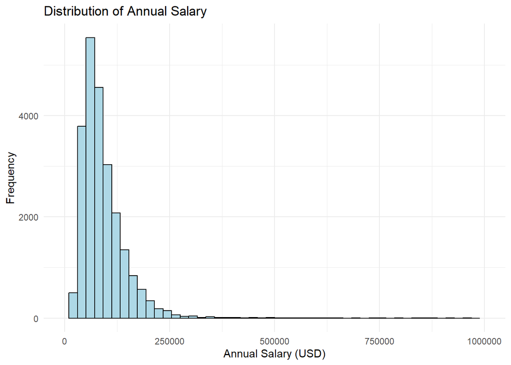

```r
# Rename from last question
us_dollars_salary <- valid_rows_exp

# Plot Annual Salary distribution

# Histogram, 14 rows greater than 1 mil
us_dollars_salary %>%
  ggplot(aes(x = Annual_Salary)) +
  geom_histogram(bins = 50, fill = "lightblue", color = "black") +
  labs(
    title = "Distribution of Annual Salary",
    x = "Annual Salary (USD)",
    y = "Frequency"
  ) +
  xlim(0, 1000000) +
  theme_minimal()
```

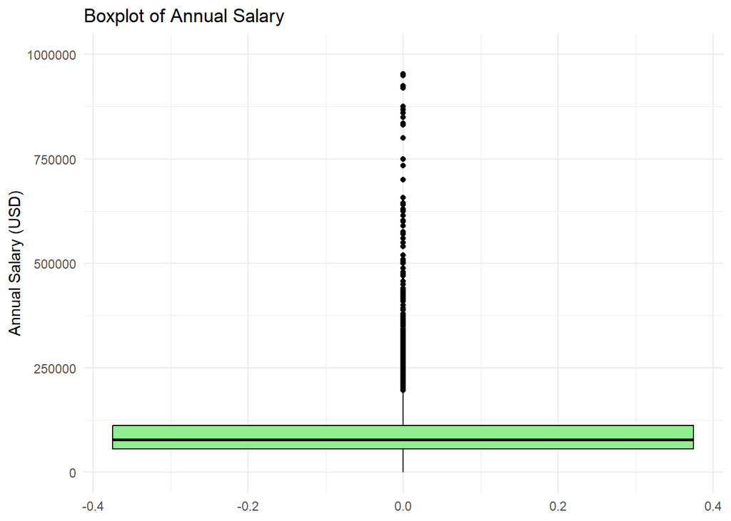

```r
# Boxplot to help identify outliers, 14 rows greater than 1 mil
us_dollars_salary %>%
  ggplot(aes(y = Annual_Salary)) +
  geom_boxplot(fill = "lightgreen", color = "black") +
  labs(
    title = "Boxplot of Annual Salary",
    y = "Annual Salary (USD)"
  ) +
  ylim(0, 1000000) + # Adjust as needed for better visualization
  theme_minimal()
```

```r
# Omit NAs-- no NAs in Annual_Salary column
us_dollars_salary <- subset(us_dollars, !is.na(Annual_Salary))

# Remove those making < $1000 per year unless they had additional compensation following above rules
us_dollars_salary2 <- us_dollars_salary[
  !(us_dollars_salary$Annual_Salary < 1000 &
    (is.na(us_dollars_salary$Additional_Compensation) |
       us_dollars_salary$Additional_Compensation < 1000)),
]

# Remove specific  billionaire outlier
us_dollars_salary3 <- us_dollars_salary2[
  !(us_dollars_salary2$Annual_Salary == 102000000),
]

# Get max and min
max(us_dollars_salary3$Annual_Salary)
```

```
[1] 1e+07
```

```r
min(us_dollars_salary3$Annual_Salary)
```

```
[1] 0
```

```r
median(us_dollars_salary3$Annual_Salary)
```

```
[1] 78560
```

```r
# Get number of observations
nrow(us_dollars_salary3)
```

```
[1] 23307
```

### f. (Optional) If you want to see this analysis through for no credit, answer the research question of whether there is a statistical association between education and salary, controlling for years of experience.

Controlling for years of total experience, we do see a statistically significant association between education and salary. Of course, we are not including all possible confounding factors into our regression model, so we can’t make any causal conclusions.

```r
# Create a df that converts factors to numbers
us_dollars_nums <- us_dollars_salary3

# Convert factors to numeric values
us_dollars_nums$Years_Experience_Total <- as.numeric((us_dollars_salary3$Years_Experience_Total))
us_dollars_nums$Years_Experience_Field <- as.numeric((us_dollars_salary3$Years_Experience_Field))

# Correlation
cor(us_dollars_nums$Years_Experience_Total, us_dollars_nums$Years_Experience_Field,
    use = "complete.obs")
```

```
[1] 0.7550524
```

```r
library(lmtest)
# Fit regression
salary_model <- lm(Annual_Salary ~ Education_Level + Years_Experience_Total,
                   data = us_dollars_salary3)

# Display the summary of the model
summary_lm <- summary(salary_model)

print(summary_lm)
```

```
Call:
lm(formula = Annual_Salary ~ Education_Level + Years_Experience_Total,
    data = us_dollars_salary3)

Residuals:
    Min      1Q  Median      3Q     Max
-179087  -32435  -11950   17907 9750913

Coefficients:
                                                  Estimate Std. Error t value
(Intercept)                                       125030.4     8403.1  14.879
Education_LevelCollege degree                     -26737.6     8344.2  -3.204
Education_LevelHigh School                        -33864.7     9702.0  -3.490
Education_LevelMaster's degree                    -23451.5     8373.1  -2.801
Education_LevelPhD                                 -3083.8     8825.1  -0.349
Education_LevelProfessional degree (MD, JD, etc.)  36061.4     8821.1   4.088
Education_LevelSome college                       -42745.3     8674.4  -4.928
Years_Experience_Total.L                           89271.2     6152.3  14.510
Years_Experience_Total.Q                           36745.7     5963.4   6.162
Years_Experience_Total.C                           26451.8     4992.5   5.298
Years_Experience_Total^4                           22636.0     3877.5   5.838
Years_Experience_Total^5                           11475.6     2878.6   3.987
Years_Experience_Total^6                            6932.9     2091.8   3.314
Years_Experience_Total^7                             743.2     1535.2   0.484
                                                  Pr(>|t|)
(Intercept)                                        < 2e-16 ***
Education_LevelCollege degree                     0.001356 **
Education_LevelHigh School                        0.000483 ***
Education_LevelMaster's degree                    0.005101 **
Education_LevelPhD                                0.726768
Education_LevelProfessional degree (MD, JD, etc.) 4.36e-05 ***
Education_LevelSome college                       8.38e-07 ***
Years_Experience_Total.L                           < 2e-16 ***
Years_Experience_Total.Q                          7.30e-10 ***
Years_Experience_Total.C                          1.18e-07 ***
Years_Experience_Total^4                          5.36e-09 ***
Years_Experience_Total^5                          6.72e-05 ***
Years_Experience_Total^6                          0.000920 ***
Years_Experience_Total^7                          0.628344
---
Signif. codes:  0 '***' 0.001 '**' 0.01 '*' 0.05 '.' 0.1 ' ' 1

Residual standard error: 101800 on 23293 degrees of freedom
Multiple R-squared:  0.03756,   Adjusted R-squared:  0.03703
F-statistic: 69.93 on 13 and 23293 DF,  p-value: < 2.2e-16
```

## Problem 3 - Palindromic Numbers

### a. Write function isPalindromic that checks if a given positive integer is a palindrome. Be sure to provide a reasonable error on an invalid input. Be sure to document your function (see instructions above).

- Input: A positive integer
- Output: A list with two elements:
- isPalindromic: A logical value indicating if the input is palindromic.
- reversed: The input with its digits reversed.

```r
#' Check if number is palindromic
#'
#' This function checks if a given positive integer is a palindromic number and returns
#' both a logical value if input is palindromic and the reversed version of the input.
#'
#' @param number A positive integer.
#'
#' @return A list with two elements:
#' - `isPalindromic`: A logical value indicating if the input is palindromic.
#' - `reversed`: The input with its digits reversed.
#'
#' @examples
#' isPalindromic(728827)
#' isPalindromic(39951)
#'
#'
isPalindromic <- function(number) {

  # Check if input is numeric first
  if (!is.numeric(number)) {

    # If given a string, try to be nice and convert for user
    warning("number must be numeric, attempting to convert")
    number <- as.numeric(number)

    if(!is.numeric(number)){ # Check again
      stop("number must be numeric or convertible")
    }
  }
  # Check if number is positive
  if(number <= 0){
    stop("number must be positive")
  }
  # Check if number is an integer (no decimals)
  if(number != as.integer(number)){
    stop("number must be an integer")
  }

  # If it passes all those checks we can move on
  # Convert the number to a string, reverse it, and convert back to number
  num_str <- as.character(number)

  # Reversing code from ChatGPT, asked how to use paste to reverse a string
  # Reverse string without converting back to numeric first for cases where number ends in 0
  reversed_str <- paste0(rev(strsplit(num_str, NULL)[[1]]), collapse = "")

  # Check if the number is palindromic by comparing the string directly
  is_palindrome <- (num_str == reversed_str)

  # Check if the reversed number ends with a zero
  if (grepl("^0", reversed_str)) {
    message("The number ends with a zero. Outputting the reversed string.")
    reversed_num <- reversed_str
  }
  # All other numbers
  else {
    reversed_num <- as.numeric(reversed_str)
  }
  # Return results
  return(list(isPalindromic = is_palindrome, reversed = reversed_num))
}

# Trying function out
isPalindromic(728827)
```

```
$isPalindromic
[1] TRUE

$reversed
[1] 728827
```

```r
isPalindromic(39951)
```

```
$isPalindromic
[1] FALSE

$reversed
[1] 15993
```

```r
isPalindromic(120)
```

```
The number ends with a zero. Outputting the reversed string.
```

```
$isPalindromic
[1] FALSE

$reversed
[1] "021"
```

### b. Create a function nextPalindrome that finds the next palindromic number strictly greater than the input. Be sure to provide a reasonable error on an invalid input.

- Input: A positive integer
- Output: A vector of length 1 with the next palindromic number greater than the input

```r
#' Find the next palindromic number
#'
#' This function finds the next palindromic number that is strictly greater
#' than the provided positive integer input.
#'
#' @param number A positive integer.
#'
#' @return A numeric value of the next palindromic number greater than the input.
#'
#' @examples
#' nextPalindrome(7152)
#' nextPalindrome(765431537)
#'
#'
nextPalindrome <- function(number) {

  # Check if input is numeric first
  if (!is.numeric(number)) {
    # If given a string, try to be nice and convert for user
    warning("number must be numeric, attempting to convert")
    number <- as.numeric(number)

    if(!is.numeric(number)){ # Check again
      stop("number must be numeric or convertible")
    }
  }
  # Check if number is positive
  if(number <= 0){
    stop("number must be positive")
  }
  # Check if number is an integer (no decimals)
  if(number != as.integer(number)){
    stop("number must be an integer")
  }

  # Start searching from the next number
  candidate <- number + 1

  # Function from first question to check if a number is palindromic
  # Write again inside this so we don't have depend on running part a to do this function
  is_palindrome <- function(num) {
    num_str <- as.character(num)
    reversed_str <- paste0(rev(strsplit(num_str, NULL)[[1]]), collapse = "")
    return(num_str == reversed_str)
  }

  # Loop until a palindromic number is found
  while (TRUE) {
    # Check if the candidate is palindromic
    if (is_palindrome(candidate)) {
      return(candidate)
    }
    # Increment the candidate to check the next number
    candidate <- candidate + 1
  }
}

# Testing function
nextPalindrome(7152)  # 7227
```

```
[1] 7227
```

```r
nextPalindrome(765431537)  # 765434567
```

```
[1] 765434567
```

```r
nextPalindrome(120)
```

```
[1] 121
```

```r
nextPalindrome(012)
```

```
[1] 22
```

### c. Use these functions to find the next palindrome for each of the following:

- 391
- 9928
- 19272719
- 109
- 2

```r
nextPalindrome(391)
```

```
[1] 393
```

```r
nextPalindrome(9928)
```

```
[1] 9999
```

```r
nextPalindrome(19272719)
```

```
[1] 19277291
```

```r
nextPalindrome(109)
```

```
[1] 111
```

```r
nextPalindrome(2)
```

```
[1] 3
```